# Data Art Challenge: Global warming through data

Claudio Desideri

# The Dataset

Dataset: [Download NASA GISTEMP CSV](https://data.giss.nasa.gov/gistemp/tabledata_v4/GLB.Ts+dSST.csv)

Let’s prepare it like we have seen in the `nasa.Rmd` part during the course.

```r
library(tidyverse)

load_or_save_data <- function(data, filename, folder = "data") {
  if (!dir.exists(folder)) {
    dir.create(folder)
  }

  file_path <- file.path(folder, filename)

  if (file.exists(file_path)) {
    message("Loading dataset from: ", file_path)
    return(read_csv(
  url,
  skip = 1,
  na = c("***", "****"),
  show_col_types = FALSE
))
  } else {
    message("Saving dataset to: ", file_path)
    write_csv(data, file_path)
    return(data)
  }
}

# URL for the NASA GISTEMP dataset
url <- "https://data.giss.nasa.gov/gistemp/tabledata_v4/GLB.Ts+dSST.csv"

# load or save the data
nasa_data <- read_csv(
  url,
  skip = 1,
  na = c("***", "****"),
  show_col_types = FALSE
) |>
  load_or_save_data("GLB.Ts+dSST.csv")

head(nasa_data)
```

```
## # A tibble: 6 × 19
##    Year   Jan   Feb   Mar   Apr   May   Jun   Jul   Aug   Sep   Oct   Nov   Dec
##   <dbl> <dbl> <dbl> <dbl> <dbl> <dbl> <dbl> <dbl> <dbl> <dbl> <dbl> <dbl> <dbl>
## 1  1880 -0.19 -0.25 -0.1  -0.17 -0.1  -0.21 -0.19 -0.11 -0.15 -0.23 -0.22 -0.18
## 2  1881 -0.2  -0.15  0.03  0.05  0.06 -0.19  0    -0.03 -0.15 -0.22 -0.19 -0.07
## 3  1882  0.15  0.13  0.04 -0.17 -0.15 -0.23 -0.17 -0.07 -0.14 -0.24 -0.17 -0.36
## 4  1883 -0.29 -0.37 -0.12 -0.18 -0.17 -0.08 -0.07 -0.14 -0.21 -0.11 -0.23 -0.11
## 5  1884 -0.13 -0.08 -0.36 -0.4  -0.34 -0.35 -0.31 -0.28 -0.27 -0.25 -0.34 -0.31
## 6  1885 -0.59 -0.34 -0.27 -0.42 -0.45 -0.44 -0.34 -0.31 -0.28 -0.23 -0.24 -0.11
## # ℹ 6 more variables: `J-D` <dbl>, `D-N` <dbl>, DJF <dbl>, MAM <dbl>,
## #   JJA <dbl>, SON <dbl>
```

```r
temp <- nasa_data |>
  select(Year, Jan:Dec) |>
  pivot_longer(
    cols = Jan:Dec,
    names_to = "month",
    values_to = "anomaly"
  ) |>
  mutate(
    month = factor(month, levels = month.abb),
    date = as.Date(
      paste(Year, month, "01", sep = "-"),
      format = "%Y-%b-%d"
    )
  ) |>
  drop_na(anomaly)

head(temp, n = 12)
```

[output not shown]

# My Data Art

I’ll create a visual expression of the data in order to communicate there is global warming. I’ve put months on the X axis and years on the Y axis, having time passing from top to bottom.

The lines are drawn in segments, one for each month, with a different color depending on the temperature anomaly and a slightly different y again depending on the anomaly.

I like the resulting rectangle that resembles oil painting and impressionism a bit, an artistic movement that used colors and shades to express feelings rather than real photorealistic scenes. My main goal was to make the viewer feel the danger we’re running into by the damage of global warming.

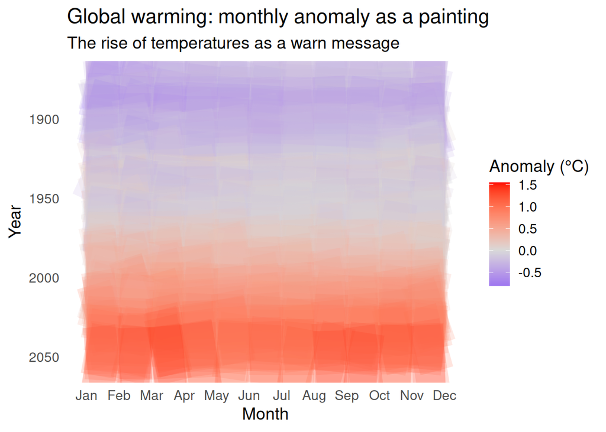

```r
temp_smooth <- temp |>
  arrange(Year, month) |>
  group_by(Year) |>
  mutate(
    month_num = as.numeric(month),
    smooth_anom = as.numeric(loess(anomaly ~ month_num)$fitted)
  ) |>
  ungroup()

p <- ggplot(arrange(temp, Year), aes(x = month, y = Year + anomaly * 20, color = anomaly)) +
  geom_line(aes(group = Year), linewidth = 25.6, alpha = 0.18) +
  scale_color_gradient2(low = "blue", mid = "gray85", high = "red",
                        midpoint = 0, name = "Anomaly (°C)") +
  labs(x = "Month", y = "Year",
       title = "Global warming: monthly anomaly as a painting",
       subtitle = "The rise of temperatures as a warn message") +
  scale_y_reverse() +
  theme_minimal(base_size = 14) +
  theme(panel.grid = element_blank(),
        legend.position = "right")

ggsave("global_warming_waves.png", p, width = 14, height = 10, dpi = 300)

p
```

# Cropped version

Here is a cropped version.

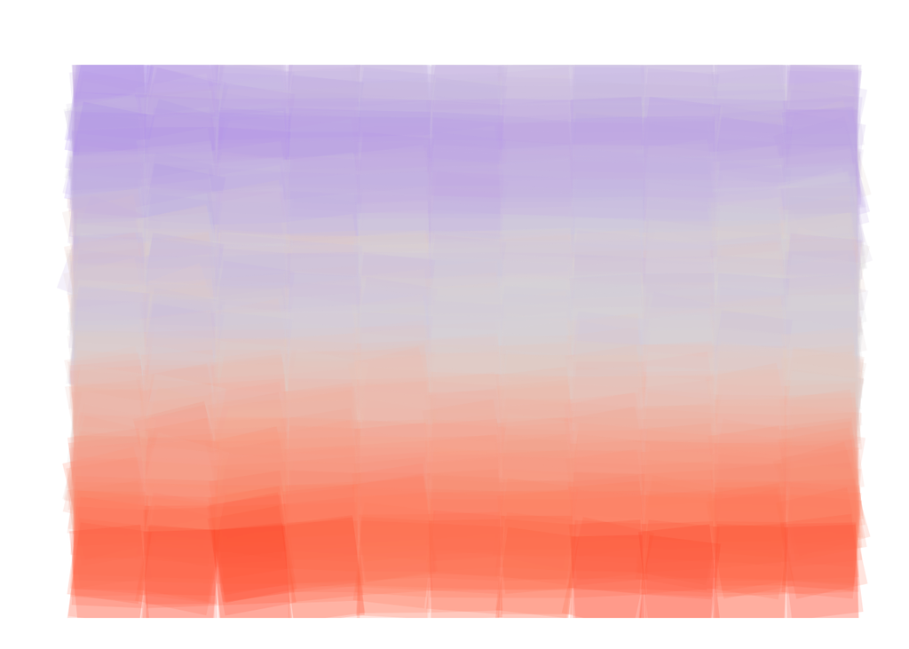

```r
pc <- ggplot(arrange(temp, Year), aes(x = month, y = Year + anomaly * 20, color = anomaly)) +
  geom_line(aes(group = Year), linewidth = 25.6, alpha = 0.18) +
  scale_color_gradient2(low = "blue", mid = "gray85", high = "red",
                        midpoint = 0, name = "Anomaly (°C)") +
  labs(x = "", y = "",
       title = "",
       subtitle = "") +
  scale_y_reverse() +
  theme_minimal(base_size = 10) +
  theme(panel.grid = element_blank(),
        legend.position = "none",
        axis.text = element_blank())
ggsave("global_warming_waves_cropped.png", pc, width = 10, height = 10, dpi = 300)
pc
```